# Introduction: All In Churn Analysis

This notebook is intended for those who are new to python and Machine Learning or working on Churn Analysis. The purpose of this notebook is to provide a comprehensive introduction to "must know of machine learning with python" also. I purposely avoid jumping into complicated models and coming directly to results in order to show the basics of how to get started in machine learning! Any comments or suggestions are much appreciated.

Below are the some "must know of machine learning" and how to do them in python. The notebook contains few complete functions and one-liner code to do all the needful. So feel free to use them in any way.

## What is Customer Churn Analysis?

It is the customer attrition rate in an organisation. Companies do this analysis to identify the cause of the churn and to implement effective strategies for retention. Churn analysis is a binary classification problem, our target variable is also binary i.e. either YES or NO. In this notebook, we will use Telco Customer churn data: https://www.kaggle.com/pangkw/telco-churn

## Index:

- Loading Libraries
- Loading Data
- EDA (Exploratory Data Analysis)
- Few techniques to handle Imbalanced data
- Handling Missing Values
- Encoding Categorical Variables
  - Label Encoding
  - One-hot Coding
- Correlation Heat Map
- Implement of few machine learning classification algorithm
  - GradientBoostingClassifier
  - Random Forest Classifier
- How to measure churn Analysis Model performance....

## Loading Libraries

Python has libraries which have inbuilt functions to make things easier. We'll keep things and will use them... :P

```python
import numpy as np
import pandas as pd
from sklearn.preprocessing import LabelEncoder
# we will use matplotlib for plotting
import matplotlib.pyplot as plt
# to suppress warning we import warning because no body likes red output in codes ... :P
import warnings
warnings.filterwarnings("ignore")
```

## Loading Data

```python
df = pd.read_csv("Telco_Customer_Churn.csv")
# df.head()
```

## EDA (Exploratory Data Analysis)

Exploratory Data Analysis is a process of initial investigations on data so as to discover patterns, to spot anomalies, to test a hypothesis and to check assumptions with the help of summary statistics and graphical representations. We will start with dataframe i.e. columns structure and datatype of columns, basically to know what kind of values and data we are going to handle.

```python
for col in df:
    print ("Column",col ," has " ,df[col].nunique() ," unique values" , df[col].unique())
```

```
Column customerID  has  7043  unique values ['7590-VHVEG' '5575-GNVDE' '3668-QPYBK' ... '4801-JZAZL' '8361-LTMKD'
 '3186-AJIEK']
Column gender  has  2  unique values ['Female' 'Male']
Column SeniorCitizen  has  2  unique values [0 1]
Column Partner  has  2  unique values ['Yes' 'No']
Column Dependents  has  2  unique values ['No' 'Yes']
Column tenure  has  73  unique values [ 1 34  2 45  8 22 10 28 62 13 16 58 49 25 69 52 71 21 12 30 47 72 17 27
  5 46 11 70 63 43 15 60 18 66  9  3 31 50 64 56  7 42 35 48 29 65 38 68
 32 55 37 36 41  6  4 33 67 23 57 61 14 20 53 40 59 24 44 19 54 51 26  0
 39]
Column PhoneService  has  2  unique values ['No' 'Yes']
Column MultipleLines  has  3  unique values ['No phone service' 'No' 'Yes']
Column InternetService  has  3  unique values ['DSL' 'Fiber optic' 'No']
Column OnlineSecurity  has  3  unique values ['No' 'Yes' 'No internet service']
Column OnlineBackup  has  3  unique values ['Yes' 'No' 'No internet service']
Column DeviceProtection  has  3  unique values ['No' 'Yes' 'No internet service']
Column TechSupport  has  3  unique values ['No' 'Yes' 'No internet service']
Column StreamingTV  has  3  unique values ['No' 'Yes' 'No internet service']
Column StreamingMovies  has  3  unique values ['No' 'Yes' 'No internet service']
Column Contract  has  3  unique values ['Month-to-month' 'One year' 'Two year']
Column PaperlessBilling  has  2  unique values ['Yes' 'No']
Column PaymentMethod  has  4  unique values ['Electronic check' 'Mailed check' 'Bank transfer (automatic)'
 'Credit card (automatic)']
Column MonthlyCharges  has  1585  unique values [29.85 56.95 53.85 ... 63.1  44.2  78.7 ]
Column TotalCharges  has  3834  unique values ['30' '1890' '108' ... '1991' '7363' '6845']
Column Churn  has  2  unique values ['No' 'Yes']
```

```python
# Checking what is the the datatype structure of our data
df.dtypes.value_counts()
```

```
object     18
int64       2
float64     1
dtype: int64
```

```python
# This function will tell about the datatype of each column
for col in df:
    print(col , df[col].dtypes)
```

```
customerID object
gender object
SeniorCitizen int64
Partner object
Dependents object
tenure int64
PhoneService object
MultipleLines object
InternetService object
OnlineSecurity object
OnlineBackup object
DeviceProtection object
TechSupport object
StreamingTV object
StreamingMovies object
Contract object
PaperlessBilling object
PaymentMethod object
MonthlyCharges float64
TotalCharges object
Churn object
```

```python
# Now lets see our target variable distribution
le = LabelEncoder()
le.fit(df['Churn'])
df['Churn'] = le.transform(df['Churn'])
df['Churn'].value_counts()
```

```
0    5174
1    1869
Name: Churn, dtype: int64
```

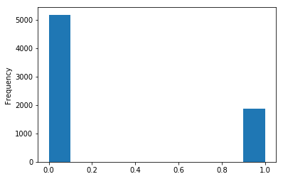

```python
df['Churn'].astype(int).plot.hist();
plt.show()
```

Our target variable distribution is 73:27, that makes our event rate to 27%, which is not very low. So we will not do any oversampling or undersampling (These are the technique to handle imbalance data). An imbalanced dataset is where our event rate is very low at 2%-5%. This is a general problem an analyst face while doing churn analysis.

## Few techniques to handle Imbalanced data:

Undersampling

- Random undersampling
- Tomek links
- Cluster Centroids

Oversampling

- Random oversampling
- Synthetic Minority Oversampling (SMOTE)

Combination of both (If required)

As imbalanced dataset problem is itself a big topic and our data is not imbalanced, we will have a complete different notebook for it with a suitable dataset, so we will move on to our next topic.

## Handling Missing Values

In real-world, most of the time data has missing values. And it is important to handle them in machine learning because many algorithms cannot handle missing data. So for the same below is the function, which tells how many columns has missing values and how many values are missing in each column.

```python
def missing_values_table(df):
        # Total missing values
        missing_val = df.isnull().sum()

        # Percentage of missing values
        missing_val_percent = 100 * df.isnull().sum() / len(df)

        # Make a table with the results
        missing_val_table = pd.concat([missing_val, missing_val_percent], axis=1)

        # Rename the columns
        missing_val_table_ren_columns = missing_val_table.rename(
        columns = {0 : 'Missing Values', 1 : '% of Total Values'})

        # Sort the table by percentage of missing descending
        missing_val_table_ren_columns = missing_val_table_ren_columns[
            missing_val_table_ren_columns.iloc[:,1] != 0].sort_values(
        '% of Total Values', ascending=False).round(1)

        # Print some summary information
        print ("Your selected dataframe has " + str(df.shape[1]) + " columns.\n"
            "There are " + str(missing_val_table_ren_columns.shape[0]) +
              " columns that have missing values.")

        # Return the dataframe with missing information
        return missing_val_table_ren_columns

missing_values = missing_values_table(df)
missing_values
```

```
Your selected dataframe has 21 columns.
There are 0 columns that have missing values.
```

|  | Missing Values | % of Total Values |
| --- | --- | --- |

#### In our case we don't have any columns with missing values, so we will move on. But there are few ways to handle them like:

- Replacing them with mean, median, mode etc....
- Removing them if we have lots of data points and it will not cause any information loss.
- In case only a few columns miss data in few rows, we can create a separate model to find the missing values.

# Encoding Categorical Variables

Before we go any further, we need to handle categorical variables as in python we cannot fit the categorical variable in most of the machine learning algorithm. There are few algorithms which can handle without any error like LightGBM. That is why we have to find a way to encode (represent) these variables as numbers before handing them off to the model. There are two main ways to encode:

## Label Encoding :

The first way is Label encoding, which is basically assigning a number to categories, but we will use this technique only for those columns where the number of distinct variable count is either two or less. For example, we can do label encoding for the gender column, where only two categories are present (male, Female). So it will give male 0 and female 1 or vis-a-vis.

[figure not shown]

(For image refer to "wrong label coding" image in the folder) Here we can treat the column as to know the person is Female or not..? For more clarity read below (section: One-Hot coding)

But if the number of unique values are more than two ->

[figure not shown]

(Refer to "Correct Label coding" image in the folder) Here carrot having greater value than apple and banana does not make any sense. So we will not do label encoding for more than two unique counts for any categorical column.

```python
# Create a label encoder object
le = LabelEncoder()
count = 0
# Iterate through the columns
for col in df:
    if df[col].dtype == 'object':
        # If 2 or fewer unique categories
        if len(list(df[col].unique())) <= 2:
            # Train on the training data
            le.fit(df[col])
            # Transform both training and testing data
            df[col] = le.transform(df[col])
            # Keep track of how many columns were label encoded
            count = count + 1
            print(col , 'column is label encoded.')
print('%d columns were label encoded.' % count)
```

```
gender column is label encoded.
Partner column is label encoded.
Dependents column is label encoded.
PhoneService column is label encoded.
PaperlessBilling column is label encoded.
5 columns were label encoded.
```

# Correlation Heatmap

Finding correlation amoung of all the numerical columns is the one of the first step to analyse the relationship between any two columns. We will produce correlation heatmap for the same purpose. Below code will create heat map for any data.

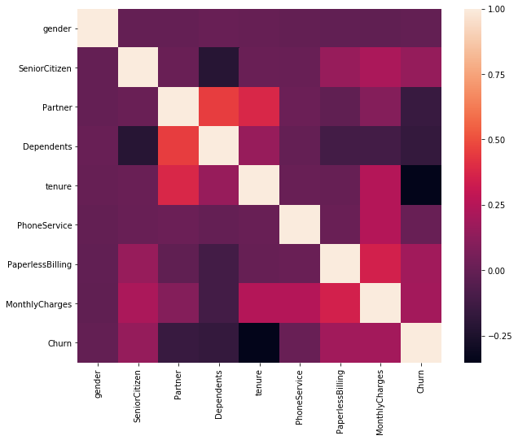

```python
#Identify numerical columns to produce a heatmap, and produce heat map
import seaborn as sns
numcols = [x for x in df.columns]
plt.figure(figsize = (10,8))
sns.heatmap(data=df[numcols].corr())
plt.show()
plt.gcf().clear()
```

# One-hot Coding

Now lets look at my personal favourite topic, One-Hot encoding. In lable encoding section(mentioned above), we saw a problem where we have more than two categorical values in a column (Fruits example). The solution of that problem is One-hot encoding

[figure not shown]

(Refer to Correct one hot coding image in the folder) One hot encodng create a new binary variable for each unique categoriacl value. In our case Three columns to show, First: is this Apple or not, Second: is this Banana or not, Third: is this carrot or not.

```python
data = pd.DataFrame()
columns = 0
for col in df:
    if df[col].dtype == 'object':
        if 2 < len(list(df[col].unique()))< 50:
            data[col] = df[col]
            df = df.drop(col, axis=1)
            columns = columns + 1
print('%d columns can be one hot encoded.' % columns)
```

```
10 columns can be one hot encoded.
```

```python
# We drop customerID and TotalCharges
#data = data.drop(['customerID', 'TotalCharges'], axis=1)
df.shape
data = pd.get_dummies(data)
print(data.shape)
data.head()
```

```
(7043, 31)
```

|  | MultipleLines_No | MultipleLines_No phone service | MultipleLines_Yes | InternetService_DSL | InternetService_Fiber optic | InternetService_No | OnlineSecurity_No | OnlineSecurity_No internet service | OnlineSecurity_Yes | OnlineBackup_No | ... | StreamingMovies_No | StreamingMovies_No internet service | StreamingMovies_Yes | Contract_Month-to-month | Contract_One year | Contract_Two year | PaymentMethod_Bank transfer (automatic) | PaymentMethod_Credit card (automatic) | PaymentMethod_Electronic check | PaymentMethod_Mailed check |
| --- | --- | --- | --- | --- | --- | --- | --- | --- | --- | --- | --- | --- | --- | --- | --- | --- | --- | --- | --- | --- | --- |
| 0 | 0 | 1 | 0 | 1 | 0 | 0 | 1 | 0 | 0 | 0 | ... | 1 | 0 | 0 | 1 | 0 | 0 | 0 | 0 | 1 | 0 |
| 1 | 1 | 0 | 0 | 1 | 0 | 0 | 0 | 0 | 1 | 1 | ... | 1 | 0 | 0 | 0 | 1 | 0 | 0 | 0 | 0 | 1 |
| 2 | 1 | 0 | 0 | 1 | 0 | 0 | 0 | 0 | 1 | 0 | ... | 1 | 0 | 0 | 1 | 0 | 0 | 0 | 0 | 0 | 1 |
| 3 | 0 | 1 | 0 | 1 | 0 | 0 | 0 | 0 | 1 | 1 | ... | 1 | 0 | 0 | 0 | 1 | 0 | 1 | 0 | 0 | 0 |
| 4 | 1 | 0 | 0 | 0 | 1 | 0 | 1 | 0 | 0 | 1 | ... | 1 | 0 | 0 | 1 | 0 | 0 | 0 | 0 | 1 | 0 |

5 rows × 31 columns

```python
# After all lets create create dataframe, which can be used for modeeling.
df_for_modelling = pd.concat([df.reset_index(drop=True) , data ], axis=1)
#df_for_modelling.head()
```

## Implement of few Machine Learing classification algorithm

```python
# Taking target variable as y
y = df_for_modelling['Churn']
# Removing or dropping columns which have no relation with target variable
X = df_for_modelling.drop(['customerID', 'Churn','TotalCharges'], axis=1)
```

```python
# Splitting the dataset into the Training set and Test set
from sklearn.model_selection import train_test_split
X_train, X_test, y_train, y_test = train_test_split(X, y, test_size = 0.20, random_state = 0)
```